# Structural Topic Modeling in Aitchison Geometry: Blog Posts on the 2008 US Presidential Election

egscatm package

2026-03-15

# 1 Introduction

`egscatm` fits a **Structural Topic Model in Aitchison geometry** via a closed-form spectral solution. Document–topic proportions live on the probability simplex $\mathcal{S}^K$ and are linked to document-level covariates through a Generalized Structured Component Analysis (GSCA) formulation. Estimation reduces to a **single eigendecomposition**—no iterative algorithm, no random initialisation, no local optima.

This vignette walks through a complete analysis of `poliblog5k`, a corpus of 5 000 US political blog posts collected during the 2008 presidential campaign and distributed with the `stm` package (Roberts, Stewart & Tingley, 2019).

## 1.1 The ILR-EGSCA model in brief

For $M$ documents, $N$ terms, $K$ topics and $P$ covariates:

| Symbol | Dimension | Meaning |
| --- | --- | --- |
| $\mathbf{W}$ | $M \times N$ | Document–term matrix |
| $\mathbf{C}$ | $M \times P$ | Covariate matrix (column-centred) |
| $\mathbf{\Pi}$ | $M \times K$ | **Topic proportions** (rows $\in \mathcal{S}^K$) |
| $\boldsymbol{\Phi}$ | $K \times N$ | Topic–term loadings |
| $\mathbf{B}_z$ | $P \times (K{-}1)$ | Covariate path coefficients in ILR space |

The model solves

$$\min_{\mathbf{Z},\boldsymbol{\Psi},\mathbf{B}_z,\boldsymbol{\mu}}
\left\|
\widetilde{\mathbf{W}} - \tfrac{1}{K}\,\mathbf{Z}\boldsymbol{\Psi}
\right\|_F^2
+
\lambda\,\left\|\mathbf{Z} - \mathbf{C}\mathbf{B}_z\right\|_F^2,
\qquad
\text{s.t.}\; \mathbf{Z}^\top\mathbf{Z} = \mathbf{I}_{K-1},$$

where $\mathbf{Z}$ are the ILR topic scores and $\widetilde{\mathbf{W}}$ is the row-centred document–term matrix. After profiling out $\boldsymbol{\Psi}$, $\mathbf{B}_z$ and $\boldsymbol{\mu}$, the problem reduces to the top-$(K{-}1)$ eigendecomposition of the $M \times M$ matrix

$$\mathbf{S}_z =
\underbrace{\widetilde{\mathbf{W}}\widetilde{\mathbf{W}}^\top}_{\text{centred
doc similarity (LSA)}}
+
\lambda\,\underbrace{\mathbf{C}(\mathbf{C}^\top\mathbf{C})^{-1}\mathbf{C}^\top}_{\text{covariate
projector } \mathbf{P}_C}.$$

$\lambda = 0$ recovers centred LSA; $\lambda \to \infty$ collapses topics onto the covariate space.

# 2 Setup

```r
# Load egscatm functions (replace with library(egscatm) once installed)
pkg_dir <- system.file("R", package = "egscatm")
if (nchar(pkg_dir) == 0L) {
  # running from source
  for (f in list.files("../R", pattern = "[.]R$", full.names = TRUE)) source(f)
} else {
  library(egscatm)
}

library(stm)   # for data and comparison
set.seed(2024)
```

# 3 Data

## 3.1 The `poliblog5k` corpus

```r
data(poliblog5k)

cat("Total documents :", length(poliblog5k.docs), "\n")
```

```
#> Total documents : 5000
```

```r
cat("Vocabulary size :", length(poliblog5k.voc),  "\n")
```

```
#> Vocabulary size : 2632
```

```r
cat("Metadata columns:", names(poliblog5k.meta),  "\n")
```

```
#> Metadata columns: rating day blog text
```

The corpus covers the period from the early 2008 primaries to the November election. Each document has two covariates:

- **`rating`** — political leaning of the blog (*Conservative* / *Liberal*).
- **`day`** — day of the campaign (integer, roughly 1–365).

```r
table(poliblog5k.meta$rating)
```

```
#>
#> Conservative      Liberal
#>         2853         2147
```

## 3.2 Sampling and vocabulary pruning

We draw a random sample of **1 000 documents** and use `prepDocuments()` to remove terms appearing in fewer than 2 documents (required by `stm`; we re-use the same pruned vocabulary for `egscatm` to ensure a fair comparison).

```r
N_sample <- 1000L
idx      <- sample.int(5000L, N_sample)

out   <- prepDocuments(
  poliblog5k.docs[idx],
  poliblog5k.voc,
  poliblog5k.meta[idx, ],
  lower.thresh = 2L,
  verbose      = FALSE
)

docs  <- out$documents
vocab <- out$vocab
meta  <- out$meta
M     <- length(docs)
V     <- length(vocab)

cat(sprintf("After pruning: %d documents, %d terms\n", M, V))
```

```
#> After pruning: 1000 documents, 2632 terms
```

## 3.3 Building the document–term matrix for `egscatm`

`egscatm` expects a dense numeric matrix $\mathbf{W} \in \mathbb{R}_{\ge 0}^{M \times N}$. We convert `stm`’s sparse list format:

```r
stm_to_dtm <- function(docs, V) {
  W <- matrix(0.0, length(docs), V)
  for (i in seq_along(docs)) {
    d <- docs[[i]]
    W[i, d[1L, ]] <- d[2L, ]
  }
  W
}

W <- stm_to_dtm(docs, V)
cat(sprintf("DTM: %d x %d,  sparsity %.1f%%\n",
            nrow(W), ncol(W), 100 * mean(W == 0)))
```

```
#> DTM: 1000 x 2632,  sparsity 94.9%
```

## 3.4 Covariate matrix

We use two covariates: political leaning (0/1) and campaign day (centred).

```r
C <- scale(
  cbind(rating = as.integer(meta$rating == "Liberal"),
        day    = meta$day),
  center = TRUE, scale = FALSE
)
colnames(C) <- c("Liberal", "day")
head(round(C, 2))
```

```
#>      Liberal     day
#> [1,]    0.57  -93.32
#> [2,]   -0.43 -168.32
#> [3,]    0.57  -14.32
#> [4,]    0.57  -22.32
#> [5,]   -0.43   20.68
#> [6,]    0.57  -16.32
```

# 4 Fitting the model

`egscatm()` requires only $\mathbf{W}$, $\mathbf{C}$, the number of topics $K$, and the regularisation weight $\lambda$. The default `scale_W = TRUE` row-normalises $\mathbf{W}$ to term frequencies before fitting.

```r
K      <- 7L
lambda <- 3.0

t_start <- proc.time()
fit <- egscatm(W, C, K = K, lambda = lambda, scale_W = TRUE)
t_fit   <- proc.time() - t_start

cat(sprintf("Fit completed in %.2f seconds (elapsed)\n", t_fit["elapsed"]))
```

```
#> Fit completed in 5.11 seconds (elapsed)
```

## 4.1 Eigenvalue spectrum

The top $K - 1 = 6$ eigenvalues of $\mathbf{S}_z$ quantify how much variance in the covariate-augmented document similarity is captured by each ILR direction.

```r
ev_df <- data.frame(
  Direction  = paste0("ILR", seq_len(K - 1L)),
  Eigenvalue = round(fit$eigenvalues, 3),
  Cumulative = round(cumsum(fit$eigenvalues) / sum(fit$eigenvalues_all), 3)
)
knitr::kable(ev_df, align = "lrr",
             caption = "Top eigenvalues of $S_z$")
```

Top eigenvalues of $S_z$

| Direction | Eigenvalue | Cumulative |
| --- | --- | --- |
| ILR1 | 3.063 | 0.401 |
| ILR2 | 3.009 | 0.795 |
| ILR3 | 0.517 | 0.863 |
| ILR4 | 0.300 | 0.902 |
| ILR5 | 0.177 | 0.925 |
| ILR6 | 0.144 | 0.944 |

The first two eigenvalues dominate and correspond to the covariate projector $\lambda \mathbf{P}_C$ (with $\lambda = 3$, this term contributes up to $3 \times \text{rank}(\mathbf{C}) = 6$ to the trace). The remaining directions capture purely textual variance (LSA signal).

# 5 Topic–term structure

## 5.1 Top-10 keywords per topic

```r
tt <- top_terms(fit, n = 10L, vocab = vocab)

for (k in seq_len(K)) {
  cat(sprintf("Topic %d : %s\n", k, paste(tt[k, ], collapse = "  |  ")))
}
```

```
#> Topic 1 : one  |  year  |  can  |  govern  |  time  |  stori  |  world  |  forc  |  didn  |  global
#> Topic 2 : mccain  |  said  |  bush  |  iraq  |  know  |  presid  |  say  |  sen  |  john  |  report
#> Topic 3 : palin  |  mccain  |  report  |  one  |  sarah  |  know  |  joe  |  peopl  |  financi  |  crisi
#> Topic 4 : obama  |  mccain  |  campaign  |  barack  |  john  |  hillari  |  poll  |  clinton  |  lead  |  say
#> Topic 5 : obama  |  hillari  |  clinton  |  barack  |  presid  |  polit  |  administr  |  public  |  white  |  news
#> Topic 6 : democrat  |  vote  |  republican  |  voter  |  parti  |  elect  |  poll  |  hillari  |  senat  |  candid
#> Topic 7 : will  |  bush  |  iraq  |  presid  |  democrat  |  war  |  republican  |  troop  |  iran  |  vote
```

The topics capture coherent themes from the 2008 campaign:

[output not shown]

## 5.2 ILR topic–term deviation matrix

The matrix $\hat{\boldsymbol{\Psi}} \in \mathbb{R}^{(K-1) \times N}$ captures topic-specific word deviations in ILR coordinates. Each row is the ILR projection of one direction; positive entries indicate words *over-represented* relative to the corpus baseline in that direction.

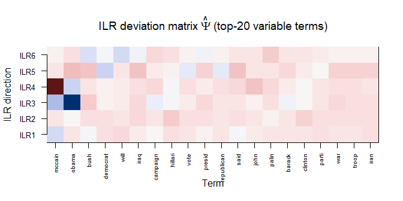

```r
# Show the 20 most variable terms across ILR directions
term_var <- apply(fit$Psi, 2L, var)
top_var  <- order(term_var, decreasing = TRUE)[1:20]

image(
  t(fit$Psi[, top_var]),
  xaxt = "n", yaxt = "n",
  col  = hcl.colors(64, "Blue-Red 3"),
  main = expression(paste("ILR deviation matrix ", hat(Psi),
                          " (top-20 variable terms)")),
  xlab = "Term", ylab = "ILR direction"
)
axis(1, at = seq(0, 1, length.out = 20),
     labels = vocab[top_var], las = 2, cex.axis = 0.65)
axis(2, at = seq(0, 1, length.out = K - 1L),
     labels = paste0("ILR", seq_len(K - 1L)), las = 1, cex.axis = 0.8)
```

# 6 Document–topic proportions

## 6.1 Distribution across the corpus

`fit$Pi` is an $M \times K$ matrix; each row sums to 1 by construction (the closure map $\text{softmax}(\mathbf{V}\mathbf{z}_i^*)$ is the exact inverse of the ILR transformation, not an approximation).

```r
cat("Row-sum range:", range(round(rowSums(fit$Pi), 10)), "\n")
```

```
#> Row-sum range: 1 1
```

```r
cat("Min proportion:", min(fit$Pi), "\n")
```

```
#> Min proportion: 0.1229359
```

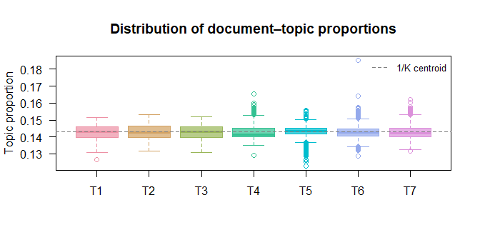

```r
boxplot(
  fit$Pi,
  names  = paste0("T", seq_len(K)),
  col    = hcl.colors(K, "Set 2", alpha = 0.7),
  border = hcl.colors(K, "Set 2"),
  ylab   = "Topic proportion",
  main   = "Distribution of document–topic proportions",
  las    = 1
)
abline(h = 1 / K, lty = 2, col = "grey50")
legend("topright", "1/K centroid", lty = 2, col = "grey50", bty = "n",
       cex = 0.8)
```

The median of each topic is close to $1/K \approx 0.14$ — this is expected: the ILR centroid $\mathbf{z} = \mathbf{0}$ maps exactly to the uniform composition, so the *average* topic proportion is $1/K$ by construction. The spread reflects how strongly individual documents deviate from the centroid.

# 7 Covariate effects

## 7.1 ILR path coefficients $\hat{\mathbf{B}}_z$

$\hat{\mathbf{B}}_z \in \mathbb{R}^{P \times (K-1)}$ gives the OLS regression of the ILR topic scores on the covariates. Column $k$ describes how covariate $p$ shifts the topic composition along the $k$-th ILR direction.

```r
Bz_df <- as.data.frame(round(fit$Bz, 4))
rownames(Bz_df) <- c("Liberal (vs Conservative)", "day (centred)")
colnames(Bz_df) <- paste0("ILR", seq_len(K - 1L))
knitr::kable(Bz_df,
             caption = "Path coefficients $\\hat{\\mathbf{B}}_z$")
```

Path coefficients $\hat{\mathbf{B}}_z$

|  | ILR1 | ILR2 | ILR3 | ILR4 | ILR5 | ILR6 |
| --- | --- | --- | --- | --- | --- | --- |
| Liberal (vs Conservative) | -0.0631 | 0.0104 | 0.0011 | -0.0019 | -2e-04 | 6e-04 |
| day (centred) | 0.0000 | -0.0003 | 0.0000 | 0.0000 | 0e+00 | 0e+00 |

## 7.2 Mean topic prevalence by leaning

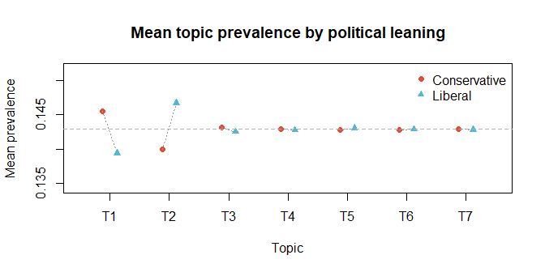

```r
prev_cons <- colMeans(fit$Pi[meta$rating == "Conservative", ])
prev_lib  <- colMeans(fit$Pi[meta$rating == "Liberal",      ])

x   <- seq_len(K)
ylim <- range(c(prev_cons, prev_lib)) + c(-0.005, 0.005)

plot(x - 0.12, prev_cons, pch = 19, col = "#E64B35",
     xlim = c(0.5, K + 0.5), ylim = ylim,
     xlab = "Topic", ylab = "Mean prevalence",
     main = "Mean topic prevalence by political leaning",
     xaxt = "n")
points(x + 0.12, prev_lib, pch = 17, col = "#4DBBD5")
axis(1, at = x, labels = paste0("T", x))
legend("topright",
       legend = c("Conservative", "Liberal"),
       pch    = c(19, 17),
       col    = c("#E64B35", "#4DBBD5"),
       bty    = "n")
abline(h = 1/K, lty = 2, col = "grey70")
segments(x - 0.12, prev_cons, x + 0.12, prev_lib,
         col = "grey60", lty = 3)
```

```r
delta_df <- data.frame(
  Topic        = paste0("T", seq_len(K)),
  Conservative = round(prev_cons, 4),
  Liberal      = round(prev_lib,  4),
  Delta        = round(prev_lib - prev_cons, 4),
  Leaning      = ifelse(prev_lib > prev_cons, "Liberal ↑", "Conservative ↑")
)
knitr::kable(delta_df, align = "lrrrr",
             caption = "Mean prevalence difference (Liberal − Conservative)")
```

Mean prevalence difference (Liberal − Conservative)

| Topic | Conservative | Liberal | Delta | Leaning |
| --- | --- | --- | --- | --- |
| T1 | 0.1455 | 0.1394 | -0.0061 | Conservative ↑ |
| T2 | 0.1400 | 0.1467 | 0.0067 | Liberal ↑ |
| T3 | 0.1431 | 0.1425 | -0.0007 | Conservative ↑ |
| T4 | 0.1429 | 0.1427 | -0.0002 | Conservative ↑ |
| T5 | 0.1427 | 0.1430 | 0.0003 | Liberal ↑ |
| T6 | 0.1428 | 0.1429 | 0.0000 | Liberal ↑ |
| T7 | 0.1429 | 0.1428 | -0.0001 | Conservative ↑ |

## 7.3 Prevalence over time

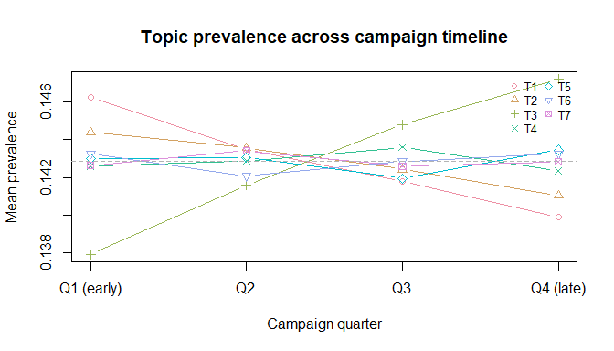

```r
# Bin campaign days into quartiles for visualisation
day_q <- cut(meta$day, breaks = quantile(meta$day, c(0,.25,.5,.75,1)),
             include.lowest = TRUE,
             labels = c("Q1 (early)", "Q2", "Q3", "Q4 (late)"))

prev_time <- t(sapply(levels(day_q), function(q)
  colMeans(fit$Pi[day_q == q, ])))

matplot(prev_time, type = "b", pch = seq_len(K),
        col = hcl.colors(K, "Set 2"),
        xaxt = "n",
        xlab = "Campaign quarter", ylab = "Mean prevalence",
        main = "Topic prevalence across campaign timeline",
        lty  = 1)
axis(1, at = seq_len(4), labels = levels(day_q))
abline(h = 1/K, lty = 2, col = "grey70")
legend("topright", paste0("T", seq_len(K)),
       pch = seq_len(K), col = hcl.colors(K, "Set 2"),
       bty = "n", ncol = 2, cex = 0.8)
```

# 8 Prediction on new documents

`predict.egscatm()` projects new documents onto the fitted topic space via the ILR loadings $\hat{\boldsymbol{\Psi}}$ without refitting.

```r
# Hold out 50 documents for prediction
idx_new  <- sample.int(M, 50L)
W_new    <- W[idx_new, ]
Pi_new   <- predict(fit, W_new, scale_W = TRUE)

cat("Predicted Pi dimensions:", dim(Pi_new), "\n")
```

```
#> Predicted Pi dimensions: 50 7
```

```r
cat("Row-sum range:", range(round(rowSums(Pi_new), 10)), "\n")
```

```
#> Row-sum range: 1 1
```

```r
# Top predicted topic per document
top_topic <- apply(Pi_new, 1L, which.max)
cat("Topic distribution in new docs:\n")
```

```
#> Topic distribution in new docs:
```

```r
print(table(paste0("T", top_topic)))
```

```
#>
#> T1 T2 T3 T4 T5 T6 T7
#> 16 10  7  6  2  3  6
```

# 9 Bootstrap standard errors for path coefficients

`ilr_se()` estimates standard errors for $\hat{\mathbf{B}}_z$ via nonparametric bootstrap resampling of documents.

```r
se_res <- ilr_se(fit, W, C, B = 100L, seed = 42L, verbose = FALSE)

se_df <- as.data.frame(round(se_res$se, 5))
rownames(se_df) <- rownames(Bz_df)
colnames(se_df) <- paste0("ILR", seq_len(K - 1L))
knitr::kable(se_df,
             caption = "Bootstrap SE for $\\hat{\\mathbf{B}}_z$ (B = 100)")
```

Bootstrap SE for $\hat{\mathbf{B}}_z$ (B = 100)

|  | ILR1 | ILR2 | ILR3 | ILR4 | ILR5 | ILR6 |
| --- | --- | --- | --- | --- | --- | --- |
| Liberal (vs Conservative) | 0.06271 | 0.01388 | 0.00111 | 0.00177 | 5e-04 | 0.00064 |
| day (centred) | 0.00005 | 0.00031 | 0.00000 | 0.00000 | 0e+00 | 0.00000 |

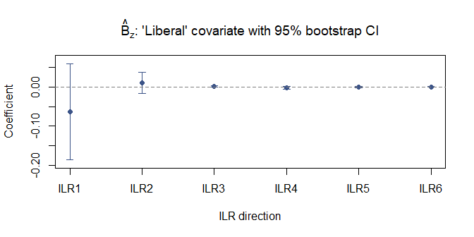

```r
# Plot Bz +/- 1.96*SE for the 'Liberal' covariate (row 1)
bz_liberal <- fit$Bz[1L, ]
se_liberal  <- se_res$se[1L, ]

ci_lo <- bz_liberal - 1.96 * se_liberal
ci_hi <- bz_liberal + 1.96 * se_liberal
dirs  <- seq_len(K - 1L)

plot(dirs, bz_liberal, pch = 19, col = "#3C5488",
     ylim = range(c(ci_lo, ci_hi)) + c(-0.01, 0.01),
     xaxt = "n",
     xlab = "ILR direction", ylab = "Coefficient",
     main = expression(paste(hat(B)[z],
       ": 'Liberal' covariate with 95% bootstrap CI")))
arrows(dirs, ci_lo, dirs, ci_hi,
       length = 0.05, angle = 90, code = 3, col = "#3C5488")
abline(h = 0, lty = 2, col = "grey50")
axis(1, at = dirs, labels = paste0("ILR", dirs))
```

# 10 Summary

```r
print(fit)
```

```
#> ILR-EGSCA Structural Topic Model
#>   Topics (K)    : 7
#>   Lambda        : 3
#>   Documents (M) : 1000
#>   Terms (N)     : 2632
#>   Covariates (P): 2
```

Model summary

| Parameter | Value |
| --- | --- |
| Documents (M) | 1000.00 |
| Terms (N) | 2632.00 |
| Topics (K) | 7.00 |
| Covariates (P) | 2.00 |
| Lambda (λ) | 3.00 |
| Fit time (s) | 5.11 |

## 10.1 Key properties

- **Non-iterative**: the solution is the top-$(K{-}1)$ eigenspace of an $(r + P) \times (r + P)$ matrix ($r \le \min(M, N, 100)$) — no random initialisation, no convergence issues, fully deterministic.
- **Globally optimal**: for the profiled, linearised ILR-EGSCA objective (Ky Fan theorem).
- **Simplex-consistent**: topic proportions satisfy $\hat{\pi}_{ik} \ge 0$ and $\sum_k \hat{\pi}_{ik} = 1$ by construction — not through post-hoc clipping.
- **Compositional**: the structural penalty $\lambda \|\mathbf{Z} - \mathbf{C}\mathbf{B}_z\|_F^2$ equals the sum of squared **Aitchison distances** between observed and covariate-predicted topic compositions (isometry of ILR).